# MA5761 Homework #2

Karthik Garimella

For homework assignments in this course, you will be provided with a knitted R notebook and the .rmd file used to create it. You are *encouraged* (but not required) to use the .rmd file as a template for your solutions.

# Exercise 1 - Pareto Distribution

The Pareto distribution has a cdf given by the formula
$$F_X(x;\alpha,\beta)=\begin{cases}1-(\frac{\beta}{x})^{\alpha}&x>\beta\\0&x\le\beta\end{cases}$$
In the above, the parameters $\alpha$ and $\beta$ are both assumed to be positive, with $\alpha$ being called the *shape parameter* and $\beta$ being called the *scale parameter*. Note that the support of this distribution depends on the value of $\beta$.

## `ppareto` function

Write a function `ppareto` which implements the above formula for the cdf. This function should take the arguments `x`, `shape` (i.e. $\alpha$), `scale` (i.e. $\beta$), along with an argument `lower.tail`. There should be a default argument of `scale = 1` and also a default argument of `lower.tail = TRUE`. When `lower.tail = FALSE` is passed to your function, it should return $1-F_X(x)$ instead of $F_X(x)$.

```r
ppareto = function(x, shape, scale = 1, lower.tail = TRUE ) {
#cdf for the Pareto Distribution

  if( x > scale){
    Fx = 1 - ((scale/x)^shape)
  }
  else{
    Fx = 0
  }

  if(lower.tail == TRUE) {
    Final_Fx = Fx
  } else if(lower.tail == FALSE) {
    Final_Fx = 1 - Fx
  }

  return (Final_Fx)
}
```

## `dpareto` function

Determine what the pdf of this distribution should be, recalling that
$$f_X(x)=\frac{d}{dx}\,F_X(x)$$
If need be, use Mathematica or other tools to help you with this differentiation problem.

Implement a function for the pdf and call it `dpareto`. Make sure this function takes the arguments `x`, `shape` ($\alpha$), and `scale` ($\beta$), with a default argument of 1 for the `scale` parameter.

```r
dpareto = function(x, shape, scale = 1){
#pdf for the Pareto Distribution

  Final_Fx = ifelse(x<scale, 0, (shape * (scale^shape)) / x^(shape + 1))
# for the ifelse https://www.statology.org/r-condition-has-length-1-only-first-element-will-be-used/

  return (Final_Fx)
}
```

Make a plot of several curves of the pdf on the same set of axes, with $\alpha=1$ and $\beta=1,3,5$. Make a separate plot of several curves of the pdf on the same set of axes, with $\alpha=1,3,5$ and $\beta=1$. **Note** that your pdf should be equal to 0 for $x<\beta$!

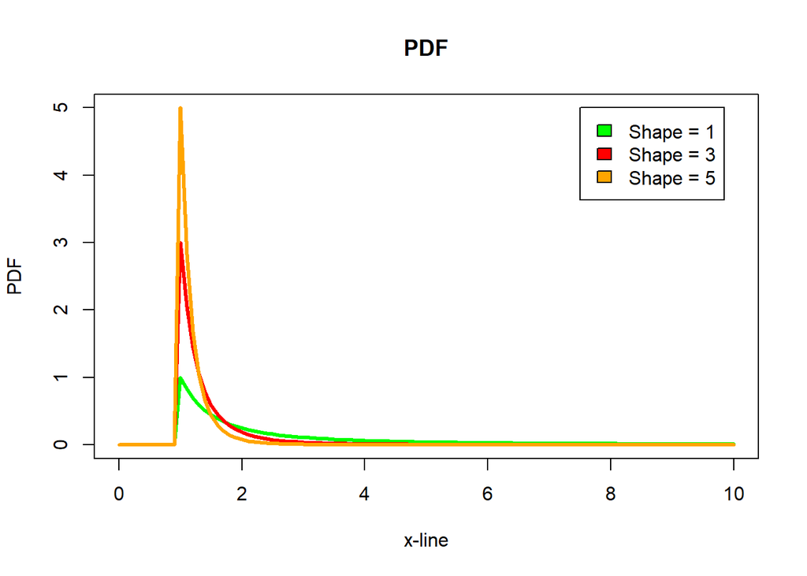

```r
#plot for different alpha (shape) with same beta (scale) - Pareto Distribution

curve(dpareto(x, shape = 1, scale = 1), from = 0, to = 10,
        ylim = c(0, 5), xlab = "x-line", ylab = "PDF", col = "green", lwd = 3)
curve(dpareto(x, shape = 3, scale = 1), add=TRUE,from = 0, to = 10,
        ylim = c(0, 5), xlab = "x-line", ylab = "PDF", col = "red", lwd = 3)
curve(dpareto(x, shape = 5, scale = 1),add=TRUE, from = 0, to = 10,
        ylim = c(0, 5), xlab = "x-line", ylab = "PDF", col = "orange", lwd = 3)
title(main = 'PDF')
legend(7.5, 5, legend=c("Shape = 1", "Shape = 3", "Shape = 5"),
       fill = c("green","red","orange"))
```

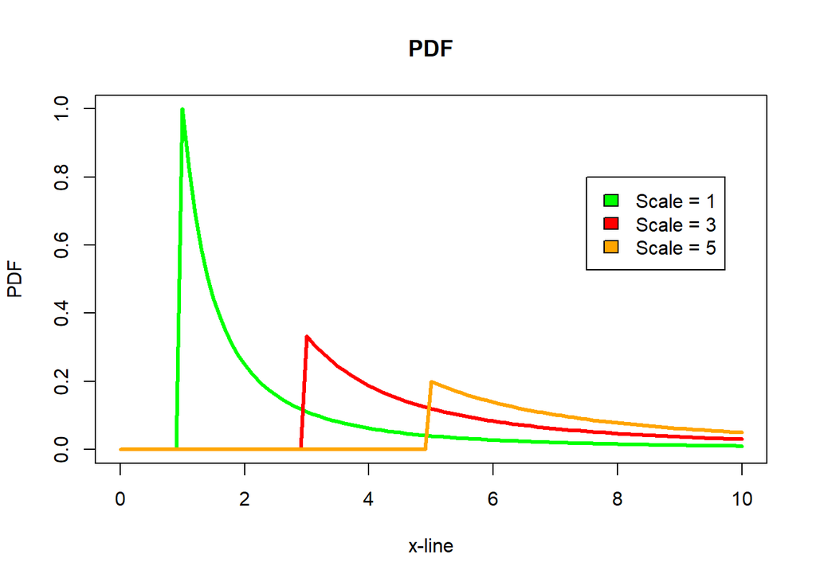

```r
#plot for different beta (scale) with same alpha (shape) - Pareto Distribution
curve(dpareto(x, shape = 1, scale = 1), from = 0, to = 10,
        ylim = c(0, 1), xlab = "x-line", ylab = "PDF", col = "green", lwd = 3)
curve(dpareto(x, shape = 1, scale = 3), add=TRUE,from = 0, to = 10,
        ylim = c(0, 1), xlab = "x-line", ylab = "PDF", col = "red", lwd = 3)
curve(dpareto(x, shape = 1, scale = 5),add=TRUE, from = 0, to = 10,
        ylim = c(0, 1), xlab = "x-line", ylab = "PDF", col = "orange", lwd = 3)
title(main = 'PDF')
legend(7.5, 0.8, legend=c("Scale = 1", "Scale = 3", "Scale = 5"),
       fill = c("green","red","orange"))
```

## `qpareto` function

Determine the quantile function $F^{-1}(x)$ for this distribution and implement this as an R function called `qpareto`. This function should take the arguments `p`, `shape`, `scale = 1`, and also `lower.tail = TRUE`. When the argument `lower.tail = FALSE` is passed to the function, it should return the value of an upper quantile (i.e. the $1-p$ quantile).

```r
qpareto = function(p, shape, scale = 1, lower.tail = TRUE){
#quantile for the Pareto Distribution

  #print(p)
  if(lower.tail == TRUE){
    F_Inv = scale * (1/(1 - p)^(1/shape))
  }
  else{
    F_Inv = 1 - (scale * (1/(1 - p)^(1/shape)))
  }

  return (F_Inv)
}
```

## `rpareto` function

Implement a function `rpareto` which generates a sample of $n$ variates from the Pareto distribution. This function should take the arguments `n`, `shape`, and `scale` (with the default value of 1 for `scale`).

```r
rpareto = function(n, shape, scale = 1){

  return(qpareto(runif(n), shape, scale))
}
```

Test out your function by generating a random sample of 10,000 replicates from the Pareto distribution with $\alpha=2$ and $\beta=4$. Create a density histogram of your sample, and overlay the pdf curve on top of it using your `dpareto` function.

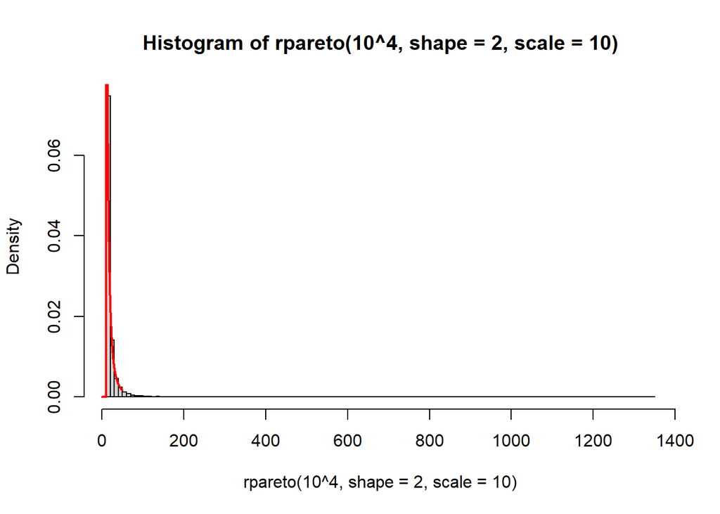

```r
# density histogram of your sample, and overlay the pdf curve on top of it using your dpareto function
hist(rpareto(10^4, shape = 2, scale = 10), breaks = 100, prob=TRUE)

curve(dpareto(x, shape = 2, scale = 10), 0, 50, add= TRUE, n = 10^4, col = "red", lwd = 2)

legend(40, 0.6, legend=c("dpareto curve"),
       fill = c("red"))
```

# Exercise 2 - Frechet Distribution

The Frechet distribution has a pdf and cdf given by the formulas
$$f_X(x;\alpha,\mu,\sigma)=\frac{\alpha}{\sigma}\left(\frac{x-\mu}{\sigma}\right)^{-(\alpha+1)}\,e^{-(\frac{x-\mu}{\sigma})^{-\alpha}},\
x>\mu$$
and
$$F_X(x;\alpha,\mu,\sigma)=\begin{cases}e^{-(\frac{x-\mu}{\sigma})^{-\alpha}}&x>\mu\\0&x\le\mu\end{cases}$$
The parameters $\alpha$, $\mu$, and $\sigma$ are called the *shape*, *location*, and *scale* parameters, respectively.

## `dfrechet` and `pfrechet` functions

```r
pfrechet = function(x,shape, location = 0, scale = 1){
#CDF of Frechet Distribution

  Fx = ifelse(x<= location, 0 ,exp(1)^(-(x - location)/scale)^(-shape))

  return(Fx)
}
```

```r
dfrechet = function(x, shape, location = 0, scale = 1){
#PDF of Frechet Distribution

  fx = ifelse( x<=location, 0 , shape/scale *  ( (x - location)/scale)^(-(shape + 1)) *
                 exp(-((x - location)/scale)^(-shape)))

  return(fx)
}
```

Write R functions which implement the pdf and cdf of this distribution. Your functions should take the arguments `x`, `shape` ($\alpha$), along with arguments taking the default values `location = 0` ($\mu$) and `scale = 1` ($\sigma$). Make sure these functions return a value of 0 when $x<\mu$.

Create some plots of the pdf for varying values of $\alpha$ while keeping the location ($\mu$) and scale ($\sigma$) parameters fixed at their default values.

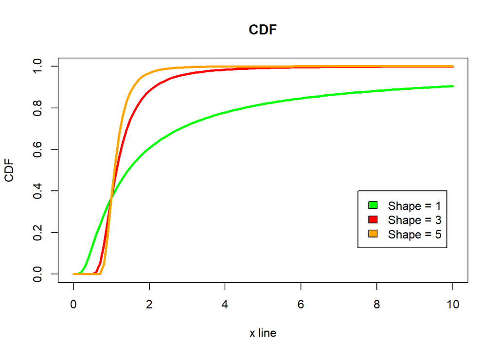

```r
#CDF plots for Frechet Distribution
curve(pfrechet(x, shape = 1, scale = 1), from = 0, to = 10,
        ylim = c(0, 1), xlab = "x line", ylab = "CDF", col = "green", lwd = 3)
curve(pfrechet(x, shape = 3, scale = 1), add=TRUE,from = 0, to = 10,
        ylim = c(0, 1), xlab = "x line", ylab = "CDF", col = "red", lwd = 3)
curve(pfrechet(x, shape = 5, scale = 1), add=TRUE, from = 0, to = 10,
      ylim = c(0, 1), xlab = "x line", ylab = "CDF", col = "orange", lwd = 3)
title(main = 'CDF')
legend(7.5, 0.4, legend=c("Shape = 1", "Shape = 3", "Shape = 5"),
       fill = c("green","red","orange"))
```

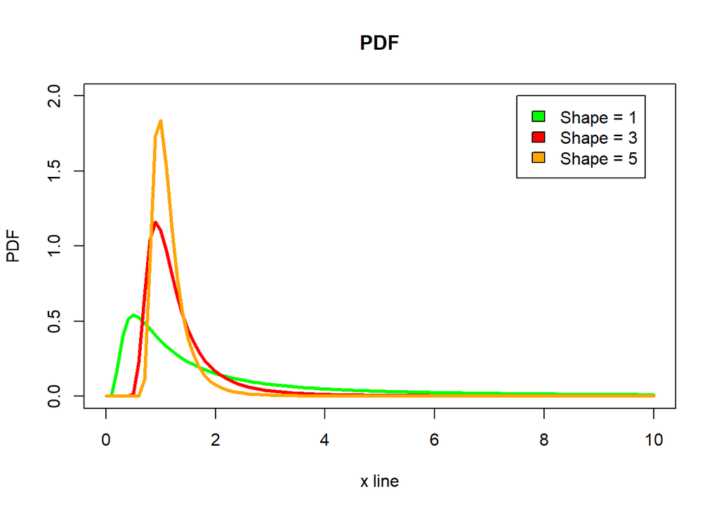

```r
#PDF plots for Frechet Distribution

curve(dfrechet(x, shape = 1, scale = 1), from = 0, to = 10,
        ylim = c(0, 2), xlab = "x line", ylab = "PDF", col = "green", lwd = 3)
curve(dfrechet(x, shape = 3, scale = 1), add=TRUE,from = 0, to = 10,
        ylim = c(0, 1), xlab = "x line", ylab = "PDF", col = "red", lwd = 3)
curve(dfrechet(x, shape = 5, scale = 1), add=TRUE, from = 0, to = 10,
      ylim = c(0, 1), xlab = "x line", ylab = "PDF", col = "orange", lwd = 3)
title(main = 'PDF')
legend(7.5, 2, legend=c("Shape = 1", "Shape = 3", "Shape = 5"),
       fill = c("green","red","orange"))
```

## `qfrechet` function

Implement the quantile function for the Frechet distribution, calling this function `qfrechet`. It should take the arguments `p`, `shape`, `location`, and `scale` (with `location = 0` and `scale = 1` being default arguments). The median of this distribution can be shown to be
$$\mu+\sigma\left(\ln(2)\right)^{-1/\alpha}$$
Verify that your `qfrechet` function is implemented correctly by calculating the median with `qfrechet` and checking it with the above formula for a few values of $\alpha$ (you can keep $\mu=0$ and $\sigma=1$).

```r
qfrechet = function(p, shape, location = 0, scale = 1){
#quantile function for Frechet Distribution
  q = location + (scale * ( (-1/log(p))^(1/shape) ) )
  return(q)
}

#median
shape_values = c(1, 2, 3)  # Different shape values
location = 0
scale = 1

qfrechet(0.5, shape_values, location, scale)
```

```
## [1] 1.442695 1.201122 1.129947
```

```r
frechet_median = location + scale * (log(2))^(-1/shape_values)
frechet_median
```

```
## [1] 1.442695 1.201122 1.129947
```

## `rfrechet` function

Write an R function, `rfrechet`, which generates a sample of size $n$ from the Frechet distribution. Your function should take the arguments `n`, `shape`, `location` and `scale` (with the default arguments `location = 0` and `scale = 1`).

```r
rfrechet = function(n, shape, location = 0, scale = 1){
#generating random variables of the Frechet Distribution
  return(qfrechet(runif(n), shape, location, scale))

#rand_num = runif(n)
#R_Fx = location + scale * ( (-1/log(rand_num))^(1/shape) )
#print(typeof(R_Fx))
#return(R_Fx)
}
```

Use your function to generate a random sample of $10^4$ variates from the Frechet distribution with $\alpha=4$, $\mu=1$, and $\sigma=2$. Create a density histogram of this sample, and overlay a plot of the pdf created with your `dfrechet` function.

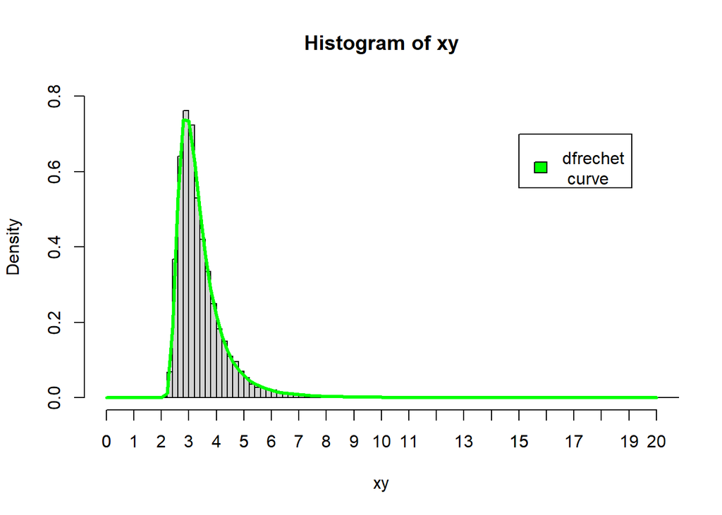

```r
#plot for rfrechet random values
xy = rfrechet(10^4, 4, 1, 2)
hist(xy, breaks = 100, prob=TRUE, xlim = c(0,20), ylim = c(0,0.8) )

curve(dfrechet(x, 4, 1, 2), add = TRUE,xlim = c(0,20), col = "green", lwd = 3)

legend(15, 0.7, legend=c("dfrechet\n curve"),
       fill = c("green"))
axis(side=1,at=seq(0,20,1), labels=seq(0,20,1))
```

The *mode* of the Frechet distribution (where the “peak” lies in the pdf) is known to be
$$\mu+\sigma\left(\frac{\alpha}{1+\alpha}\right)^{1/\alpha}$$
Calculate this number for the given parameters, and comment on whether your histogram agrees with this fact.

```r
#mode
shape = 4
location = 1
scale = 2

frechet_mode = location + scale*( (shape/(1+shape)) )^(1/shape)

frechet_mode
```

```
## [1] 2.891483
```

The mode being 2.89 ~ 2.9 looks almost similiar to what the peak is in the histogram created above. The highest frequency point seems to be just before 3 on the x-axis. So, the histogram agrees with the mode of the frechet distribution.

# Exercise 3 - Discrete Distribution

Suppose that a discrete random variable $X$ has the pmf as stated in the table below:

| $x$ | 0 | 1 | 2 | 3 | 4 | 5 |
| --- | --- | --- | --- | --- | --- | --- |
| $f_X(x)$ | 0.05 | 0.1 | 0.15 | 0.4 | 0.15 | 0.15 |

## `rdiscrete` function

Write a function, call it `rdiscrete` for lack of a better choice, which generates a random sample of $n$ variates from this distribution using the inverse transform method (i.e. do *not* just use the `sample` function). This function need only take the argument `n`, though for an interesting challenge you might consider allowing the function to further take the arguments `x` and `prob`, which would be vectors of the possible values of $X$ and their associated probabilities.

```r
#Dicrete Distribution
library("dplyr")
rdiscrete = function(n){

  x = c(-1, 0, 1, 2, 3, 4, 5)
  fx = c(0, 0.05, 0.1, 0.15, 0.4, 0.15, 0.15)

  rand =runif(n)
  sum_fx = cumsum(fx)
  R_fx = c()

for (i in rand)  {
  for (j in 1:length(sum_fx) ){
  if (between(i, sum_fx[j], sum_fx[j+1])){ #dplyr used for the between function
  R_fx = c(R_fx, x[j+1])
}
}
}

return(data.frame(rand, R_fx))

}
```

## Generate a sample

Use your `rdiscrete` function to generate a sample of $10^4$ observations from this distribution. Create a table of relative frequencies (sample proportions) of this sample, and compare it to the probabilities in the pmf.

```r
rdiscrete(10^4)
```

| rand | R_fx |
| --- | --- |
| 0.6999042453 | 3 |
| 0.8668475463 | 5 |
| 0.6416947909 | 3 |
| 0.6978362727 | 3 |
| 0.5115878046 | 3 |
| 0.9104790331 | 5 |
| 0.1433016506 | 1 |
| 0.9277712838 | 5 |
| 0.7736256886 | 4 |
| 0.2456722998 | 2 |

[output cut: 9990 more lines]